# Risk Factor Analysis

## Outcome Variable

**Outcome Variable:** pers_wast

## Predictor Variables

**Intervention Variable:** meducyrs

**Adjustment Set:**

- arm
- W_mage
- feducyrs
- W_mhtcm
- W_mwtkg
- W_mbmi
- W_gagebrth
- W_birthwt
- W_birthlen
- single
- delta_W_mage
- delta_feducyrs
- delta_W_mhtcm
- delta_W_mwtkg
- delta_W_mbmi
- delta_W_gagebrth
- delta_W_birthwt
- delta_W_birthlen
- delta_single

## Stratifying Variables

The analysis was stratified on these variable(s):

- agecat
- studyid
- country

## Data Summary

| agecat | studyid | country | meducyrs | pers_wast | n_cell | n |
| --- | --- | --- | --- | --- | --- | --- |
| 0-24 months | CMC-V-BCS-2002 | INDIA | High | 0 | 150 | 373 |
| 0-24 months | CMC-V-BCS-2002 | INDIA | High | 1 | 8 | 373 |
| 0-24 months | CMC-V-BCS-2002 | INDIA | Low | 0 | 98 | 373 |
| 0-24 months | CMC-V-BCS-2002 | INDIA | Low | 1 | 8 | 373 |
| 0-24 months | CMC-V-BCS-2002 | INDIA | Medium | 0 | 102 | 373 |
| 0-24 months | CMC-V-BCS-2002 | INDIA | Medium | 1 | 7 | 373 |
| 0-24 months | COHORTS | GUATEMALA | High | 0 | 203 | 1047 |
| 0-24 months | COHORTS | GUATEMALA | High | 1 | 6 | 1047 |
| 0-24 months | COHORTS | GUATEMALA | Low | 0 | 462 | 1047 |
| 0-24 months | COHORTS | GUATEMALA | Low | 1 | 20 | 1047 |
| 0-24 months | COHORTS | GUATEMALA | Medium | 0 | 346 | 1047 |
| 0-24 months | COHORTS | GUATEMALA | Medium | 1 | 10 | 1047 |
| 0-24 months | COHORTS | INDIA | High | 0 | 579 | 4519 |
| 0-24 months | COHORTS | INDIA | High | 1 | 31 | 4519 |
| 0-24 months | COHORTS | INDIA | Low | 0 | 1254 | 4519 |
| 0-24 months | COHORTS | INDIA | Low | 1 | 218 | 4519 |
| 0-24 months | COHORTS | INDIA | Medium | 0 | 2248 | 4519 |
| 0-24 months | COHORTS | INDIA | Medium | 1 | 189 | 4519 |
| 0-24 months | COHORTS | PHILIPPINES | High | 0 | 1013 | 2811 |
| 0-24 months | COHORTS | PHILIPPINES | High | 1 | 42 | 2811 |
| 0-24 months | COHORTS | PHILIPPINES | Low | 0 | 787 | 2811 |
| 0-24 months | COHORTS | PHILIPPINES | Low | 1 | 61 | 2811 |
| 0-24 months | COHORTS | PHILIPPINES | Medium | 0 | 867 | 2811 |
| 0-24 months | COHORTS | PHILIPPINES | Medium | 1 | 41 | 2811 |
| 0-24 months | EE | PAKISTAN | High | 0 | 15 | 374 |
| 0-24 months | EE | PAKISTAN | High | 1 | 0 | 374 |
| 0-24 months | EE | PAKISTAN | Low | 0 | 295 | 374 |
| 0-24 months | EE | PAKISTAN | Low | 1 | 31 | 374 |
| 0-24 months | EE | PAKISTAN | Medium | 0 | 31 | 374 |
| 0-24 months | EE | PAKISTAN | Medium | 1 | 2 | 374 |

[output cut: 126 more lines]

The following strata were considered:

- agecat: 0-24 months, studyid: CMC-V-BCS-2002, country: INDIA
- agecat: 0-24 months, studyid: COHORTS, country: GUATEMALA
- agecat: 0-24 months, studyid: COHORTS, country: INDIA
- agecat: 0-24 months, studyid: COHORTS, country: PHILIPPINES
- agecat: 0-24 months, studyid: EE, country: PAKISTAN
- agecat: 0-24 months, studyid: GMS-Nepal, country: NEPAL
- agecat: 0-24 months, studyid: Guatemala BSC, country: GUATEMALA
- agecat: 0-24 months, studyid: IRC, country: INDIA
- agecat: 0-24 months, studyid: JiVitA-3, country: BANGLADESH
- agecat: 0-24 months, studyid: JiVitA-4, country: BANGLADESH
- agecat: 0-24 months, studyid: LCNI-5, country: MALAWI
- agecat: 0-24 months, studyid: MAL-ED, country: BANGLADESH
- agecat: 0-24 months, studyid: MAL-ED, country: BRAZIL
- agecat: 0-24 months, studyid: MAL-ED, country: INDIA
- agecat: 0-24 months, studyid: MAL-ED, country: NEPAL
- agecat: 0-24 months, studyid: MAL-ED, country: PERU
- agecat: 0-24 months, studyid: MAL-ED, country: SOUTH AFRICA
- agecat: 0-24 months, studyid: MAL-ED, country: TANZANIA, UNITED REPUBLIC OF
- agecat: 0-24 months, studyid: NIH-Birth, country: BANGLADESH
- agecat: 0-24 months, studyid: NIH-Crypto, country: BANGLADESH
- agecat: 0-24 months, studyid: PROBIT, country: BELARUS
- agecat: 0-24 months, studyid: PROVIDE, country: BANGLADESH
- agecat: 0-24 months, studyid: SAS-CompFeed, country: INDIA
- agecat: 0-24 months, studyid: SAS-FoodSuppl, country: INDIA
- agecat: 0-24 months, studyid: TanzaniaChild2, country: TANZANIA, UNITED REPUBLIC OF
- agecat: 0-24 months, studyid: ZVITAMBO, country: ZIMBABWE

### Dropped Strata

Some strata were dropped due to rare outcomes:

- agecat: 0-24 months, studyid: EE, country: PAKISTAN
- agecat: 0-24 months, studyid: Guatemala BSC, country: GUATEMALA
- agecat: 0-24 months, studyid: LCNI-5, country: MALAWI
- agecat: 0-24 months, studyid: MAL-ED, country: BANGLADESH
- agecat: 0-24 months, studyid: MAL-ED, country: BRAZIL
- agecat: 0-24 months, studyid: MAL-ED, country: INDIA
- agecat: 0-24 months, studyid: MAL-ED, country: NEPAL
- agecat: 0-24 months, studyid: MAL-ED, country: PERU
- agecat: 0-24 months, studyid: MAL-ED, country: SOUTH AFRICA
- agecat: 0-24 months, studyid: MAL-ED, country: TANZANIA, UNITED REPUBLIC OF
- agecat: 0-24 months, studyid: NIH-Crypto, country: BANGLADESH
- agecat: 0-24 months, studyid: PROVIDE, country: BANGLADESH
- agecat: 0-24 months, studyid: SAS-FoodSuppl, country: INDIA
- agecat: 0-24 months, studyid: TanzaniaChild2, country: TANZANIA, UNITED REPUBLIC OF

## Methods Detail

We're interested in the causal parameters $E[Y_a]$ for all values of $a \in \mathcal{A}$. These parameters represent the mean outcome if, possibly contrary to fact, we intervened to set all units to have $A=a$. Under the randomization and positivity assumptions, these are identified by the statistical parameters $\psi_a=E_W[E_{Y|A,W}(Y|A=a,W)]$. In addition, we're interested in the mean of $Y$, $E[Y]$ under no intervention (the observed mean). We will estimate these parameters by using SuperLearner to fit the relevant likelihood factors -- $E_{Y|A,W}(Y|A=a,W)$ and $p(A=a|W)$, and then updating our likelihood fit using a joint TMLE.

For unadjusted analyses ($W=\{\}$), initial likelihoods were estimated using Lrnr_glm to estimate the simple $E(Y|A)$ and Lrnr_mean to estimate $p(A)$. For adjusted analyses, a small library containing Lrnr_glmnet, Lrnr_xgboost, and Lrnr_mean was used.

Having estimated these parameters, we will then use the delta method to estimate relative risks and attributable risks relative to a prespecified baseline level of $A$.

# Results Detail

## Results Plots

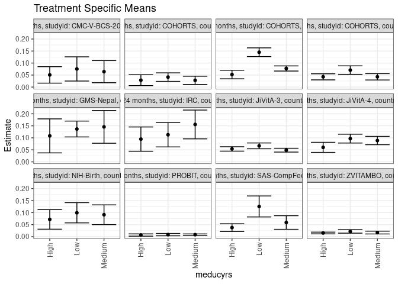

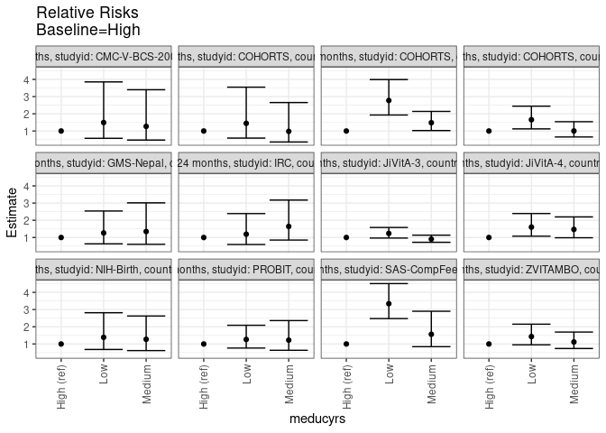

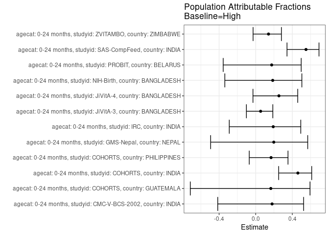

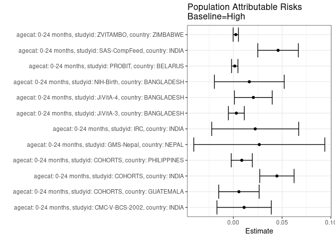

## Results Table

### Parameter: TSM

| agecat | studyid | country | intervention_level | baseline_level | estimate | ci_lower | ci_upper |
| --- | --- | --- | --- | --- | --- | --- | --- |
| 0-24 months | CMC-V-BCS-2002 | INDIA | High | NA | 0.0506329 | 0.0164006 | 0.0848652 |
| 0-24 months | CMC-V-BCS-2002 | INDIA | Low | NA | 0.0754717 | 0.0251181 | 0.1258253 |
| 0-24 months | CMC-V-BCS-2002 | INDIA | Medium | NA | 0.0642202 | 0.0181372 | 0.1103031 |
| 0-24 months | COHORTS | GUATEMALA | High | NA | 0.0287081 | 0.0060586 | 0.0513577 |
| 0-24 months | COHORTS | GUATEMALA | Low | NA | 0.0414938 | 0.0236814 | 0.0593061 |
| 0-24 months | COHORTS | GUATEMALA | Medium | NA | 0.0280899 | 0.0109180 | 0.0452618 |
| 0-24 months | COHORTS | INDIA | High | NA | 0.0522740 | 0.0344280 | 0.0701200 |
| 0-24 months | COHORTS | INDIA | Low | NA | 0.1450534 | 0.1269205 | 0.1631862 |
| 0-24 months | COHORTS | INDIA | Medium | NA | 0.0774079 | 0.0667602 | 0.0880556 |
| 0-24 months | COHORTS | PHILIPPINES | High | NA | 0.0426331 | 0.0299503 | 0.0553158 |
| 0-24 months | COHORTS | PHILIPPINES | Low | NA | 0.0706082 | 0.0529349 | 0.0882815 |
| 0-24 months | COHORTS | PHILIPPINES | Medium | NA | 0.0427616 | 0.0295344 | 0.0559887 |
| 0-24 months | GMS-Nepal | NEPAL | High | NA | 0.1081081 | 0.0372999 | 0.1789163 |
| 0-24 months | GMS-Nepal | NEPAL | Low | NA | 0.1366906 | 0.1036918 | 0.1696895 |
| 0-24 months | GMS-Nepal | NEPAL | Medium | NA | 0.1456311 | 0.0774529 | 0.2138092 |
| 0-24 months | IRC | INDIA | High | NA | 0.0946784 | 0.0442079 | 0.1451488 |
| 0-24 months | IRC | INDIA | Low | NA | 0.1127310 | 0.0621921 | 0.1632699 |
| 0-24 months | IRC | INDIA | Medium | NA | 0.1555834 | 0.0956403 | 0.2155265 |
| 0-24 months | JiVitA-3 | BANGLADESH | High | NA | 0.0537675 | 0.0446040 | 0.0629309 |
| 0-24 months | JiVitA-3 | BANGLADESH | Low | NA | 0.0665187 | 0.0544750 | 0.0785624 |
| 0-24 months | JiVitA-3 | BANGLADESH | Medium | NA | 0.0486334 | 0.0406933 | 0.0565734 |
| 0-24 months | JiVitA-4 | BANGLADESH | High | NA | 0.0603127 | 0.0393125 | 0.0813130 |
| 0-24 months | JiVitA-4 | BANGLADESH | Low | NA | 0.0967127 | 0.0783099 | 0.1151155 |
| 0-24 months | JiVitA-4 | BANGLADESH | Medium | NA | 0.0886546 | 0.0713554 | 0.1059539 |
| 0-24 months | NIH-Birth | BANGLADESH | High | NA | 0.0716655 | 0.0309396 | 0.1123915 |
| 0-24 months | NIH-Birth | BANGLADESH | Low | NA | 0.0993019 | 0.0571860 | 0.1414179 |
| 0-24 months | NIH-Birth | BANGLADESH | Medium | NA | 0.0911438 | 0.0500507 | 0.1322370 |
| 0-24 months | PROBIT | BELARUS | High | NA | 0.0066708 | 0.0020116 | 0.0113299 |
| 0-24 months | PROBIT | BELARUS | Low | NA | 0.0084188 | 0.0035626 | 0.0132750 |
| 0-24 months | PROBIT | BELARUS | Medium | NA | 0.0081599 | 0.0050491 | 0.0112707 |
| 0-24 months | SAS-CompFeed | INDIA | High | NA | 0.0375958 | 0.0215488 | 0.0536428 |
| 0-24 months | SAS-CompFeed | INDIA | Low | NA | 0.1256370 | 0.0819409 | 0.1693331 |
| 0-24 months | SAS-CompFeed | INDIA | Medium | NA | 0.0588288 | 0.0304520 | 0.0872055 |
| 0-24 months | ZVITAMBO | ZIMBABWE | High | NA | 0.0151907 | 0.0116495 | 0.0187319 |
| 0-24 months | ZVITAMBO | ZIMBABWE | Low | NA | 0.0217460 | 0.0144931 | 0.0289990 |
| 0-24 months | ZVITAMBO | ZIMBABWE | Medium | NA | 0.0169742 | 0.0111189 | 0.0228295 |

### Parameter: E(Y)

| agecat | studyid | country | intervention_level | baseline_level | estimate | ci_lower | ci_upper |
| --- | --- | --- | --- | --- | --- | --- | --- |
| 0-24 months | CMC-V-BCS-2002 | INDIA | NA | NA | 0.0616622 | 0.0372186 | 0.0861058 |
| 0-24 months | COHORTS | GUATEMALA | NA | NA | 0.0343840 | 0.0233416 | 0.0454263 |
| 0-24 months | COHORTS | INDIA | NA | NA | 0.0969241 | 0.0882972 | 0.1055510 |
| 0-24 months | COHORTS | PHILIPPINES | NA | NA | 0.0512273 | 0.0430760 | 0.0593786 |
| 0-24 months | GMS-Nepal | NEPAL | NA | NA | 0.1346801 | 0.1072037 | 0.1621566 |
| 0-24 months | IRC | INDIA | NA | NA | 0.1170732 | 0.0859146 | 0.1482317 |
| 0-24 months | JiVitA-3 | BANGLADESH | NA | NA | 0.0568153 | 0.0526983 | 0.0609323 |
| 0-24 months | JiVitA-4 | BANGLADESH | NA | NA | 0.0808042 | 0.0721841 | 0.0894244 |
| 0-24 months | NIH-Birth | BANGLADESH | NA | NA | 0.0880150 | 0.0639627 | 0.1120673 |
| 0-24 months | PROBIT | BELARUS | NA | NA | 0.0080806 | 0.0045539 | 0.0116073 |
| 0-24 months | SAS-CompFeed | INDIA | NA | NA | 0.0834553 | 0.0601989 | 0.1067118 |
| 0-24 months | ZVITAMBO | ZIMBABWE | NA | NA | 0.0176600 | 0.0150131 | 0.0203070 |

### Parameter: RR

| agecat | studyid | country | intervention_level | baseline_level | estimate | ci_lower | ci_upper |
| --- | --- | --- | --- | --- | --- | --- | --- |
| 0-24 months | CMC-V-BCS-2002 | INDIA | High | High | 1.0000000 | 1.0000000 | 1.000000 |
| 0-24 months | CMC-V-BCS-2002 | INDIA | Low | High | 1.4905660 | 0.5765449 | 3.853624 |
| 0-24 months | CMC-V-BCS-2002 | INDIA | Medium | High | 1.2683486 | 0.4732218 | 3.399481 |
| 0-24 months | COHORTS | GUATEMALA | High | High | 1.0000000 | 1.0000000 | 1.000000 |
| 0-24 months | COHORTS | GUATEMALA | Low | High | 1.4453665 | 0.5887096 | 3.548582 |
| 0-24 months | COHORTS | GUATEMALA | Medium | High | 0.9784644 | 0.3606476 | 2.654648 |
| 0-24 months | COHORTS | INDIA | High | High | 1.0000000 | 1.0000000 | 1.000000 |
| 0-24 months | COHORTS | INDIA | Low | High | 2.7748667 | 1.9296962 | 3.990206 |
| 0-24 months | COHORTS | INDIA | Medium | High | 1.4808116 | 1.0252218 | 2.138857 |
| 0-24 months | COHORTS | PHILIPPINES | High | High | 1.0000000 | 1.0000000 | 1.000000 |
| 0-24 months | COHORTS | PHILIPPINES | Low | High | 1.6561837 | 1.1229165 | 2.442696 |
| 0-24 months | COHORTS | PHILIPPINES | Medium | High | 1.0030143 | 0.6531927 | 1.540185 |
| 0-24 months | GMS-Nepal | NEPAL | High | High | 1.0000000 | 1.0000000 | 1.000000 |
| 0-24 months | GMS-Nepal | NEPAL | Low | High | 1.2643885 | 0.6291027 | 2.541204 |
| 0-24 months | GMS-Nepal | NEPAL | Medium | High | 1.3470874 | 0.6022147 | 3.013285 |
| 0-24 months | IRC | INDIA | High | High | 1.0000000 | 1.0000000 | 1.000000 |
| 0-24 months | IRC | INDIA | Low | High | 1.1906730 | 0.5929827 | 2.390799 |
| 0-24 months | IRC | INDIA | Medium | High | 1.6432839 | 0.8507526 | 3.174110 |
| 0-24 months | JiVitA-3 | BANGLADESH | High | High | 1.0000000 | 1.0000000 | 1.000000 |
| 0-24 months | JiVitA-3 | BANGLADESH | Low | High | 1.2371554 | 0.9678907 | 1.581329 |
| 0-24 months | JiVitA-3 | BANGLADESH | Medium | High | 0.9045126 | 0.7204774 | 1.135557 |
| 0-24 months | JiVitA-4 | BANGLADESH | High | High | 1.0000000 | 1.0000000 | 1.000000 |
| 0-24 months | JiVitA-4 | BANGLADESH | Low | High | 1.6035204 | 1.0745810 | 2.392819 |
| 0-24 months | JiVitA-4 | BANGLADESH | Medium | High | 1.4699159 | 0.9840100 | 2.195763 |
| 0-24 months | NIH-Birth | BANGLADESH | High | High | 1.0000000 | 1.0000000 | 1.000000 |
| 0-24 months | NIH-Birth | BANGLADESH | Low | High | 1.3856298 | 0.6815290 | 2.817151 |
| 0-24 months | NIH-Birth | BANGLADESH | Medium | High | 1.2717942 | 0.6158033 | 2.626586 |
| 0-24 months | PROBIT | BELARUS | High | High | 1.0000000 | 1.0000000 | 1.000000 |
| 0-24 months | PROBIT | BELARUS | Low | High | 1.2620371 | 0.7624818 | 2.088886 |
| 0-24 months | PROBIT | BELARUS | Medium | High | 1.2232320 | 0.6335367 | 2.361815 |
| 0-24 months | SAS-CompFeed | INDIA | High | High | 1.0000000 | 1.0000000 | 1.000000 |
| 0-24 months | SAS-CompFeed | INDIA | Low | High | 3.3417837 | 2.4756821 | 4.510885 |
| 0-24 months | SAS-CompFeed | INDIA | Medium | High | 1.5647706 | 0.8438352 | 2.901641 |
| 0-24 months | ZVITAMBO | ZIMBABWE | High | High | 1.0000000 | 1.0000000 | 1.000000 |
| 0-24 months | ZVITAMBO | ZIMBABWE | Low | High | 1.4315338 | 0.9530179 | 2.150315 |
| 0-24 months | ZVITAMBO | ZIMBABWE | Medium | High | 1.1174053 | 0.7369280 | 1.694324 |

### Parameter: PAR

| agecat | studyid | country | intervention_level | baseline_level | estimate | ci_lower | ci_upper |
| --- | --- | --- | --- | --- | --- | --- | --- |
| 0-24 months | CMC-V-BCS-2002 | INDIA | High | NA | 0.0110293 | -0.0168377 | 0.0388962 |
| 0-24 months | COHORTS | GUATEMALA | High | NA | 0.0056758 | -0.0150637 | 0.0264153 |
| 0-24 months | COHORTS | INDIA | High | NA | 0.0446501 | 0.0270352 | 0.0622650 |
| 0-24 months | COHORTS | PHILIPPINES | High | NA | 0.0085943 | -0.0022325 | 0.0194211 |
| 0-24 months | GMS-Nepal | NEPAL | High | NA | 0.0265720 | -0.0406554 | 0.0937994 |
| 0-24 months | IRC | INDIA | High | NA | 0.0223948 | -0.0222316 | 0.0670212 |
| 0-24 months | JiVitA-3 | BANGLADESH | High | NA | 0.0030478 | -0.0051221 | 0.0112178 |
| 0-24 months | JiVitA-4 | BANGLADESH | High | NA | 0.0204915 | 0.0011267 | 0.0398564 |
| 0-24 months | NIH-Birth | BANGLADESH | High | NA | 0.0163494 | -0.0194618 | 0.0521607 |
| 0-24 months | PROBIT | BELARUS | High | NA | 0.0014098 | -0.0018810 | 0.0047006 |
| 0-24 months | SAS-CompFeed | INDIA | High | NA | 0.0458596 | 0.0250560 | 0.0666631 |
| 0-24 months | ZVITAMBO | ZIMBABWE | High | NA | 0.0024693 | -0.0002770 | 0.0052156 |

### Parameter: PAF

| agecat | studyid | country | intervention_level | baseline_level | estimate | ci_lower | ci_upper |
| --- | --- | --- | --- | --- | --- | --- | --- |
| 0-24 months | CMC-V-BCS-2002 | INDIA | High | NA | 0.1788663 | -0.4151376 | 0.5235371 |
| 0-24 months | COHORTS | GUATEMALA | High | NA | 0.1650718 | -0.7149568 | 0.5935145 |
| 0-24 months | COHORTS | INDIA | High | NA | 0.4606708 | 0.2506467 | 0.6118307 |
| 0-24 months | COHORTS | PHILIPPINES | High | NA | 0.1677671 | -0.0705596 | 0.3530379 |
| 0-24 months | GMS-Nepal | NEPAL | High | NA | 0.1972973 | -0.4926666 | 0.5683352 |
| 0-24 months | IRC | INDIA | High | NA | 0.1912889 | -0.2889298 | 0.4925918 |
| 0-24 months | JiVitA-3 | BANGLADESH | High | NA | 0.0536445 | -0.1017335 | 0.1871096 |
| 0-24 months | JiVitA-4 | BANGLADESH | High | NA | 0.2535945 | -0.0301775 | 0.4591989 |
| 0-24 months | NIH-Birth | BANGLADESH | High | NA | 0.1857574 | -0.3374388 | 0.5042831 |
| 0-24 months | PROBIT | BELARUS | High | NA | 0.1744655 | -0.3552853 | 0.4971486 |
| 0-24 months | SAS-CompFeed | INDIA | High | NA | 0.5495101 | 0.3421911 | 0.6914892 |
| 0-24 months | ZVITAMBO | ZIMBABWE | High | NA | 0.1398256 | -0.0288435 | 0.2808431 |